# 11_bits_and_pieces

Gulnara Tagridzhanova

04/04/2026

**Summary:** small things that came up in revisions, too small to warrant their own report, too disjointed to make it worthwhile integrting them in existing reports

## 1. Non-Tangerine tyrRs in Xanthoria genomes

- Got this suggestion: “im curious about these other YRs: are orthologous YRs located at the same genomic locus in different genomes? How many are located near the ends of contigs? I think this information will help readers understand why only 2/20 YRs were found associated with a full-length Starship. How likely is it that more interesting starships will be found in Xanthoria if you sequence more genomes?”
- Let’s see what I can find without burying myself completely

### Non-Tangerine YRs from Xanthoria in likely HGT clades

- Only sequence from (any) Xanthoria is xanthoria.aureola.1_tyr4090 in Clade C

### Position of YRs in the assemblies

- To visualize where they are, need to do make a bed file intersecting the YR bed with the whole genome bed files with windows of 10,000 bp (the latter was preppred in `02_annotate`)

```r
#load bedtools v2.31.0
source package b0ed0698-358b-4c9b-9d21-603ea8d6e478

#let's remake bed files with windows of 10,000 bp, because the existing ones are made with the contig names that will not be consistent with the YR file
bedtools makewindows -g  analysis_and_temp_files/03_starfish/genomes/Xanthoria_parietina_GTX0501.scaffolds.fa.fai   -w 10000 > analysis_and_temp_files/11_bits_and_pieces/GTX0501.bed

bedtools makewindows -g  analysis_and_temp_files/03_starfish/genomes/Xanthoria_calcicola_GTX0491.scaffolds.fa.fai   -w 10000 > analysis_and_temp_files/11_bits_and_pieces/GTX0491.bed

bedtools makewindows -g  analysis_and_temp_files/03_starfish/genomes/Xanthoria_parietina_SAMEA111342678.scaffolds.fa.fai  -w 10000 > analysis_and_temp_files/11_bits_and_pieces/ASG.bed

bedtools makewindows -g  analysis_and_temp_files/03_starfish/genomes/Xanthoria_parietina_XpEllen.scaffolds.fa.fai  -w 10000 > analysis_and_temp_files/11_bits_and_pieces/XpEllen.bed

##GTX0501
bedtools coverage -a analysis_and_temp_files/11_bits_and_pieces/GTX0501.bed -b analysis_and_temp_files/03_starfish/geneFinder/manyxanthoria.tyr.bed > analysis_and_temp_files/11_bits_and_pieces/GTX0501_tyr_bedtools.txt

##GTX0491
bedtools coverage -a  analysis_and_temp_files/11_bits_and_pieces/GTX0491.bed -b analysis_and_temp_files/03_starfish/geneFinder/manyxanthoria.tyr.bed > analysis_and_temp_files/11_bits_and_pieces/GTX0491_tyr_bedtools.txt

#XpEllen
bedtools coverage -a analysis_and_temp_files/11_bits_and_pieces/XpEllen.bed -b analysis_and_temp_files/03_starfish/geneFinder/manyxanthoria.tyr.bed > analysis_and_temp_files/11_bits_and_pieces/XpEllen_tyr_bedtools.txt

#ASG
bedtools coverage -a analysis_and_temp_files/11_bits_and_pieces/ASG.bed -b analysis_and_temp_files/03_starfish/geneFinder/manyxanthoria.tyr.bed > analysis_and_temp_files/11_bits_and_pieces/ASG_tyr_bedtools.txt
```

- Now let’s visualize them one-by-one. GTX501 does show that most are close to a contig end

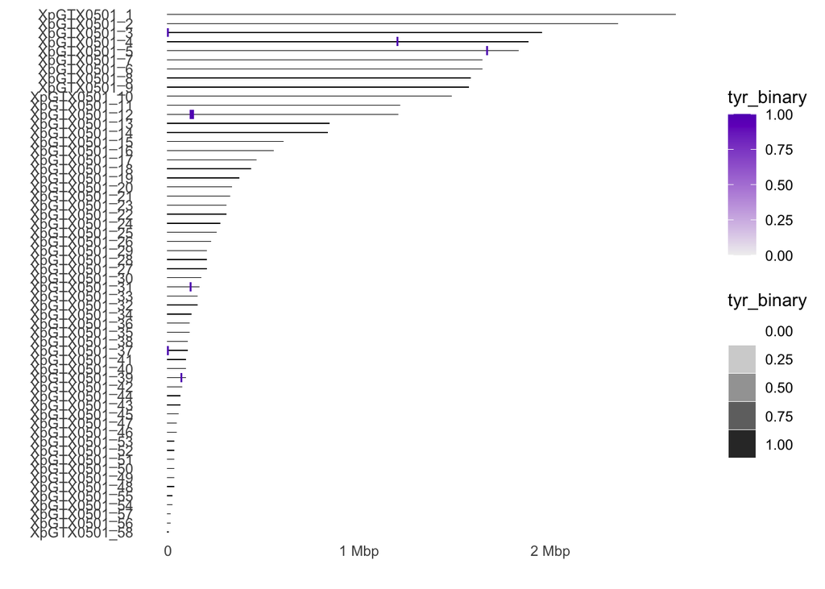

```r
plot_tyr<-function(file){
  bed_tyr<-read.delim2(file,header=F)[,c(1,2,7)]
colnames(bed_tyr)<-c("contig","window_start","tyr")
bed_tyr$tyr<-as.numeric(bed_tyr$tyr)
bed_tyr<-bed_tyr %>% mutate(tyr_binary=if_else(tyr>0,1,0))

ggplot(bed_tyr,aes(y=fct_reorder(contig,window_start),x=window_start))+
    geom_tile(aes(height=0.1),fill="black")+
  geom_tile(aes(fill=tyr_binary,alpha=tyr_binary))+
  xlab("")+ylab("")+
  scale_alpha_continuous(range=c(0,1))+
  scale_fill_gradient(low="#f0f0f0",high="#6402bf")+
   scale_x_continuous(breaks = c(0,1000000,2000000,3000000,4000000),
                     labels = c("0","1 Mbp","2 Mbp","3 Mbp","4 Mbp"))+
  theme_minimal()+
  theme(panel.grid.major = element_blank(), panel.grid.minor = element_blank())}

plot_tyr("../analysis_and_temp_files/11_bits_and_pieces/GTX0501_tyr_bedtools.txt")
```

- GTX491 has fewer just in general, although all the contigs that contain captains have telomeric repeats on both ends

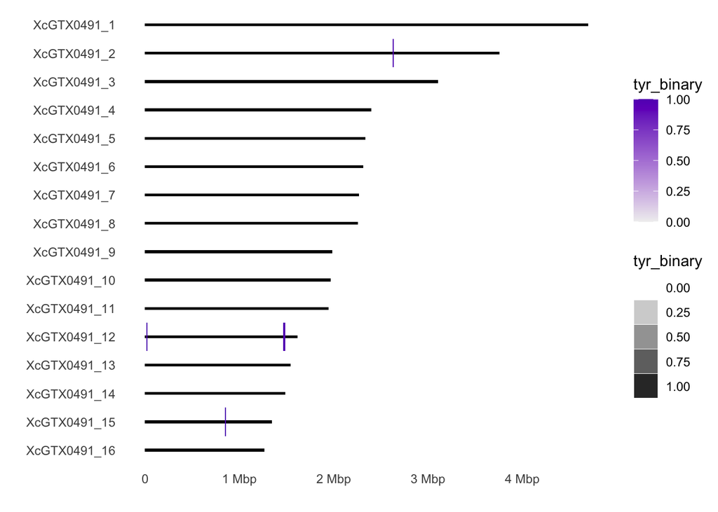

```r
plot_tyr("../analysis_and_temp_files/11_bits_and_pieces/GTX0491_tyr_bedtools.txt")
```

- ASG has two captains side-by-side on contig 35

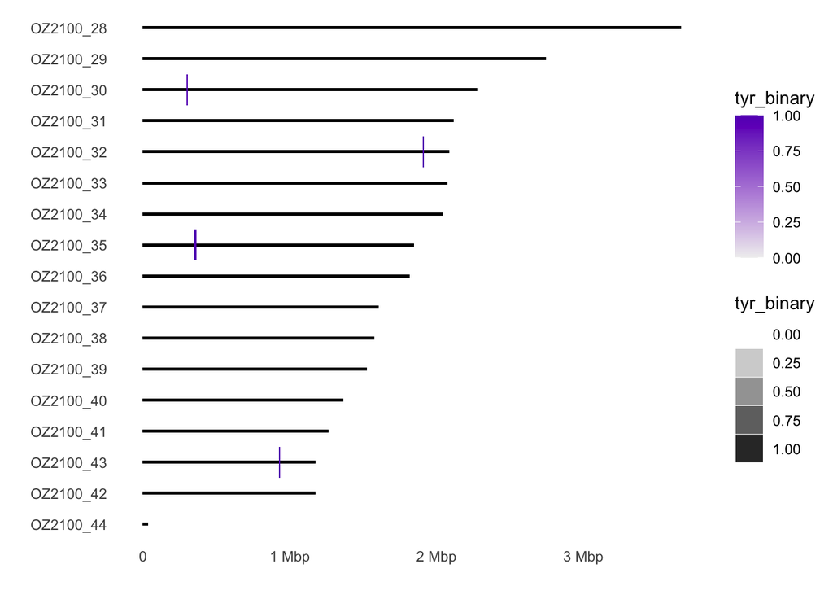

```r
plot_tyr("../analysis_and_temp_files/11_bits_and_pieces/ASG_tyr_bedtools.txt")
```

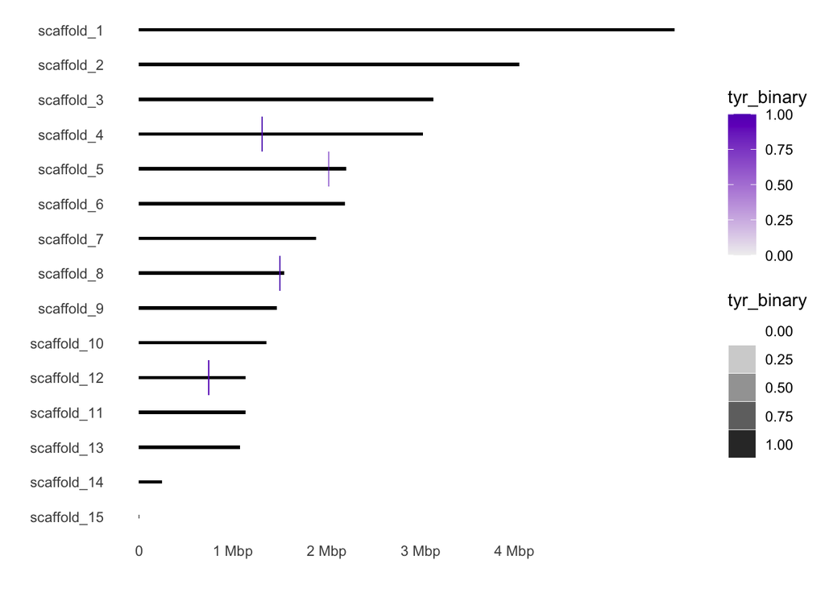

```r
plot_tyr("../analysis_and_temp_files/11_bits_and_pieces/XpEllen_tyr_bedtools.txt")
```

- The captains from the same navis: are they in the same position in the genomes?
  - In addition to Tangerine (navis0002), only two more naves are represented in >1 genome, navis0001 and navis0003
  - navis0001, phoenixFam: on all three X.parietina the placement is consistent (scaffold_5 in XpEllen, OZ2100_32 in ASG, and XpGTX0501_12 are all in the same block. GTX501 has two sequences in this navis, and the second is in XpGTX0501_4. is this again duplication caused by fragmentation?). However, in X.calcicola the sequence is not at XcGTX0491_5, as would be expected, but at XcGTX0491_15.
  - navis0003, galacticaFam: a bit all over the place. It’s in all three X.parietina but is missing in X.calcicola. It’s on the very end of contigs in two genomes (XpGTX0501_37 and scaffold_8), and not far from end on OZ2100_43. XpGTX0501_37 and scaffold_8 form an ortho block 50-60 kb, based on 17 genes. But OZ2100_43 is matching with scaffold_1!
  - navis0004 has two sequences, but both are only in GTX0501. This is probably another case on Starship related assembly break and consequent gene duplication, same as we saw with Tangerine
  - navis0005-10 have one sequence each
  - sequences from navis0008 and navis0009 sit next to each other on one contig. They both are within the third element that Starfish found, OZ2100_s00003. This element was deemed false positive, since it had an empty site >40bp, was only 17 kb, and lacked auxillary genes
- Summing up, we have two naves (navis0001 and navis0003) present in multiple genomes which have inconsistent placement, and 7 naves (navis0004-10) that are present in one genome each only. Of the latter set, only two (navis0008 and navis0009) are associated with an element

### Do they have any auxillary genes in the vicinity?

- Let’s examine gene models 100 kb up and down stream of all YRs. Will again use bedtools to get the list of genes

```r
#convert gff3 file that contains all genome annotations to bed
source package /tsl/software/testing/bin/bedops-2.4.28
gff2bed < analysis_and_temp_files/03_starfish/manyxanthorias.gff3  > analysis_and_temp_files/11_bits_and_pieces/manyxanthorias.bed

#intersect with window
bedtools window -a analysis_and_temp_files/03_starfish/geneFinder/manyxanthoria.tyr.bed -b analysis_and_temp_files/11_bits_and_pieces/manyxanthorias.bed  -w 100000 > analysis_and_temp_files/11_bits_and_pieces/manyxanthoria.tyr.vicinity.bed
```

- Let’s load the genes and check their annotations. Will need to check that the genes in the direction faced by the captain (so |-tyr-> |-gene1-> <-gene2-| )

```r
#get the list
list<-read.delim("../analysis_and_temp_files/11_bits_and_pieces/manyxanthoria.tyr.vicinity.bed",header=F) %>%
  filter(V16=="gene")
list<-list %>% mutate(TranscriptID = str_replace(V18,"Name=","")) %>%
  mutate(TranscriptID = sub(";.*", "", TranscriptID)) %>%
  select(V4,TranscriptID,V9,V10,V11)
colnames(list) <- c("tyrID","TranscriptID","Sequence","Gene_Start","Gene_End")
list$tyrID <- str_replace(list$tyrID,"OZ2100","XANPAOZ2100")
list$tyrID <- str_replace(list$tyrID,"scaffold","XANPARI20")
list$TranscriptID <- str_replace(list$TranscriptID,"XANPAEllen","XANPARI20")
list$tyrID <- str_replace(list$tyrID,"XcGTX0491","XANCAGTX0491")
list$tyrID <- str_replace(list$tyrID,"XpGTX0501","XANPAGTX0501")


#get annotations for InterPro
ann_GTX0501 <- read.delim("../analysis_and_temp_files/03_starfish/ann/Xanthoria_parietina_GTX0501.annotations.txt")
ann_GTX0491 <- read.delim("../analysis_and_temp_files/03_starfish/ann/Xanthoria_calcicola_GTX0491.annotations.txt") %>% mutate(TranscriptID = str_replace(TranscriptID,"FUN","XANCAGTX0491"))
ann_ASG <-read.delim("../analysis_and_temp_files/03_starfish/ann/Xanthoria_parietina_SAMEA111342678.annotations.txt") %>% mutate(TranscriptID = str_replace(TranscriptID,"FUN","XANPAOZ2100"))
ann_XEL <-read.delim("../analysis_and_temp_files/03_starfish/ann/Xanthoria_parietina_SAMEA115359166.annotations.txt") %>% mutate(TranscriptID = str_replace(TranscriptID,"FUN","XANPARI20"))

ann<-rbind(ann_GTX0501, ann_GTX0491 ,ann_ASG,ann_XEL) %>%
  select(TranscriptID,InterPro)

#get info on the YRs and naves
tyr <- read.delim("../results/captains.txt") %>% dplyr::rename(tyr_Start=Start,tyr_End=End)  %>%
  select(geneID, navis,family_hit,tyr_Start,tyr_End,Strand)


#combine all together
vicinity<- list %>% left_join(tyr,by=c("tyrID"="geneID")) %>%
  mutate(TranscriptID = paste0(TranscriptID,"-T1")) %>%
  left_join(ann)

#remove all genes in the wrong position compared to the captain
vicinity <- vicinity %>% filter((Strand=="+" & Gene_Start>tyr_Start) | (Strand=="-" & Gene_Start<tyr_Start))

#calculate the distance between the gene and the YR (shortest distance between ends of each gene)
vicinity <- vicinity %>% mutate(Distance1 = abs(Gene_Start-tyr_Start),
                                Distance2 = abs(Gene_Start-tyr_End),
                                Distance3 = abs(Gene_Start-tyr_Start),
                                Distance4 = abs(Gene_End-tyr_End)) %>%
  mutate(Distance = pmap(across(starts_with("Distance")),min)) %>%
  select(TranscriptID,Sequence,Gene_Start,Gene_End,tyrID,navis,family_hit,tyr_Start,tyr_End,Distance,InterPro)
vicinity$Distance <- vicinity$Distance %>% as.integer
#save
write.table(vicinity,"../analysis_and_temp_files/11_bits_and_pieces/genes_in_vicinity_tyr.txt",sep="\t",quote = F, row.names = F)
```

- Do any of them have auxillary gene annotations?
  - screened InterPro annotations
  - to identify NLRs, selected proteins that have either NACHT or NB-Arc domain and one of the three repeat domains (Ankyrin, WD40, or TPR)

```r
vicinity_filter<-vicinity %>% mutate(Auxillary_type = case_when(grepl("IPR022198",InterPro) ~ "DUF3723",
      grepl("IPR002641",InterPro) ~ "Patatin-like phospholipase",
  grepl("IPR007111",InterPro) & (grepl("IPR002110",InterPro) | grepl("IPR001680",InterPro) | grepl("IPR019734",InterPro)) ~ "NLR",
  grepl("IPR002182",InterPro) & (grepl("IPR002110",InterPro) | grepl("IPR001680",InterPro) | grepl("IPR019734",InterPro)) ~ "NLR",
     grepl("IPR013121",InterPro) ~ "Ferric reductase",
  T ~ "")) %>% filter(Auxillary_type != "") %>%
  select(TranscriptID,Sequence,Gene_Start,Gene_End,Auxillary_type,tyrID,navis,family_hit,tyr_Start,tyr_End,Distance,InterPro) %>%
  arrange(navis)


write.table(vicinity_filter,"../analysis_and_temp_files/11_bits_and_pieces/auxillary_genes_in_vicinity_tyr.txt",sep="\t",quote = F, row.names = F)

vicinity_filter %>% kable(format = "html", col.names = colnames(vicinity_filter)) %>%
  kable_styling() %>%
  kableExtra::scroll_box(width = "100%", height = "300px")
```

| TranscriptID | Sequence | Gene_Start | Gene_End | Auxillary_type | tyrID | navis | family_hit | tyr_Start | tyr_End | Distance | InterPro |
| --- | --- | --- | --- | --- | --- | --- | --- | --- | --- | --- | --- |
| XANPAOZ2100_003956-T1 | OZ2100_32 | 1867662 | 1872807 | NLR | XANPAOZ2100_003971-T1 | navis0001 | phoenixFam | 1910251 | 1912801 | 39994 | IPR001680 WD40 repeat;IPR007111 NACHT nucleoside triphosphatase;IPR015943 WD40/YVTN repeat-like-containing domain superfamily;IPR027417 P-loop containing nucleoside triphosphate hydrolase;IPR029058 Al… |
| XANPARI20_005618-T1 | scaffold_5 | 1981957 | 1987294 | NLR | XANPARI20_005633-T1 | navis0001 | phoenixFam | 2024608 | 2027212 | 39918 | IPR001680 WD40 repeat;IPR007111 NACHT nucleoside triphosphatase;IPR015943 WD40/YVTN repeat-like-containing domain superfamily;IPR027417 P-loop containing nucleoside triphosphate hydrolase;IPR029058 Al… |
| XANPAGTX0501_007322-T1 | XpGTX0501_12 | 169727 | 174774 | NLR | XANPAGTX0501_007307-T1 | navis0001 | phoenixFam | 129424 | 131974 | 37753 | IPR001680 WD40 repeat;IPR007111 NACHT nucleoside triphosphatase;IPR015943 WD40/YVTN repeat-like-containing domain superfamily;IPR027417 P-loop containing nucleoside triphosphate hydrolase;IPR029058 Al… |
| XANPAOZ2100_002164-T1 | OZ2100_30 | 362107 | 363397 | DUF3723 | XANPAOZ2100_002162-T1 | navis0002 | clade1 | 305825 | 307015 | 55092 | IPR022198 Protein of unknown function DUF3723 |
| XANPAOZ2100_002165-T1 | OZ2100_30 | 363597 | 365731 | Patatin-like phospholipase | XANPAOZ2100_002162-T1 | navis0002 | clade1 | 305825 | 307015 | 56582 | IPR002641 Patatin-like phospholipase domain;IPR016035 Acyl transferase/acyl hydrolase/lysophospholipase |
| XANPAOZ2100_002167-T1 | OZ2100_30 | 370398 | 376212 | NLR | XANPAOZ2100_002162-T1 | navis0002 | clade1 | 305825 | 307015 | 63383 | IPR002110 Ankyrin repeat;IPR007111 NACHT nucleoside triphosphatase;IPR027417 P-loop containing nucleoside triphosphate hydrolase;IPR036770 Ankyrin repeat-containing domain superfamily |
| XANPARI20_008748-T1 | scaffold_12 | 697445 | 699579 | Patatin-like phospholipase | XANPARI20_008752-T1 | navis0002 | clade1 | 744949 | 746139 | 46560 | IPR002641 Patatin-like phospholipase domain;IPR016035 Acyl transferase/acyl hydrolase/lysophospholipase |
| XANPARI20_008749-T1 | scaffold_12 | 701094 | 702351 | DUF3723 | XANPARI20_008752-T1 | navis0002 | clade1 | 744949 | 746139 | 43788 | IPR022198 Protein of unknown function DUF3723 |
| XANPARI20_008746-T1 | scaffold_12 | 686545 | 692778 | NLR | XANPARI20_008752-T1 | navis0002 | clade1 | 744949 | 746139 | 53361 | IPR002110 Ankyrin repeat;IPR007111 NACHT nucleoside triphosphatase;IPR027417 P-loop containing nucleoside triphosphate hydrolase;IPR036770 Ankyrin repeat-containing domain superfamily |
| XANPAGTX0501_001721-T1 | XpGTX0501_3 | 50164 | 52793 | Patatin-like phospholipase | XANPAGTX0501_001716-T1 | navis0002 | clade1 | 6660 | 7805 | 42359 | IPR001841 Zinc finger, RING-type;IPR002641 Patatin-like phospholipase domain;IPR016035 Acyl transferase/acyl hydrolase/lysophospholipase;IPR017907 Zinc finger, RING-type, conserved site |
| XANPAGTX0501_001724-T1 | XpGTX0501_3 | 56965 | 60805 | NLR | XANPAGTX0501_001716-T1 | navis0002 | clade1 | 6660 | 7805 | 49160 | IPR002110 Ankyrin repeat;IPR007111 NACHT nucleoside triphosphatase;IPR020683 Domain of unknown function DUF3447;IPR027417 P-loop containing nucleoside triphosphate hydrolase;IPR036770 Ankyrin repeat-c… |
| XANPAGTX0501_001720-T1 | XpGTX0501_3 | 47349 | 49964 | DUF3723 | XANPAGTX0501_001716-T1 | navis0002 | clade1 | 6660 | 7805 | 39544 | IPR022198 Protein of unknown function DUF3723 |
| XANPARI20_007356-T1 | scaffold_8 | 1485566 | 1487656 | Patatin-like phospholipase | XANPARI20_007362-T1 | navis0003 | galacticaFam | 1503178 | 1505738 | 17612 | IPR002641 Patatin-like phospholipase domain;IPR016035 Acyl transferase/acyl hydrolase/lysophospholipase |
| XANPARI20_007357-T1 | scaffold_8 | 1487932 | 1490493 | DUF3723 | XANPARI20_007362-T1 | navis0003 | galacticaFam | 1503178 | 1505738 | 15245 | IPR022198 Protein of unknown function DUF3723 |
| XANPAGTX0501_010495-T1 | XpGTX0501_37 | 23807 | 25897 | Patatin-like phospholipase | XANPAGTX0501_010485-T1 | navis0003 | galacticaFam | 760 | 1759 | 22048 | IPR002641 Patatin-like phospholipase domain;IPR016035 Acyl transferase/acyl hydrolase/lysophospholipase |
| XANPAGTX0501_010504-T1 | XpGTX0501_37 | 42340 | 46727 | Ferric reductase | XANPAGTX0501_010485-T1 | navis0003 | galacticaFam | 760 | 1759 | 40581 | IPR013112 FAD-binding 8;IPR013121 Ferric reductase, NAD binding domain;IPR017927 FAD-binding domain, ferredoxin reductase-type;IPR017938 Riboflavin synthase-like beta-barrel;IPR039261 Ferredoxin-NADP … |
| XANCAGTX0491_002185-T1 | XcGTX0491_2 | 2704381 | 2707759 | NLR | XANCAGTX0491_002172-T1 | navis0010 | clade3 | 2632559 | 2633446 | 70935 | IPR002110 Ankyrin repeat;IPR007111 NACHT nucleoside triphosphatase;IPR020683 Domain of unknown function DUF3447;IPR027417 P-loop containing nucleoside triphosphate hydrolase;IPR036770 Ankyrin repeat-c… |

- Incorporated these results in the supplementary table listing all tyrRs from Xanthoria